# Met4Heks H21 Sensorveiledning

## Oppgave 1

# Oppgave 1a

Tanken bak IRFen er at et sjokk kan ha en effekt på responsvariabelen vår lenge etter at det inntraff. IRFen kvantifiserer hvor mye et sjokk *endrer* forventningsverdien til $Y$, $k$ tidsenheter frem i tid. Ved å regne ut IRFen for forskjellige $k$ kan vi derfor få informasjon om hvordan sjokket påvirker forventningsverdien på ulike tidshorisonter. Dersom IRFen f.eks er positiv vil et sjokk øke forventningsverdien til $Y$, $k$ tidsenheter frem i tid.

# Oppgave 1b

$$\begin{equation}
\begin{split}
\text{IRF}(k) &= E(Y_{t + k}\mid \text{sjokk}_t = 1\:\text{og}\: Y_t = a) - E(Y_{t + k}\mid \text{sjokk}_t = 0\:\text{og}\: Y_t = a)\\
&= E(\alpha + \beta_1 \text{sjokk}_t + \beta_2 Y_t + \epsilon_{t + k} \mid \text{sjokk}_t = 1\:\text{og}\: Y_t = a) - E(\alpha + \beta_1 \text{sjokk}_t + \beta_2 Y_t + \epsilon_{t + k} \mid \text{sjokk}_t = 0\:\text{og}\: Y_t = a)\\
&= \alpha + \beta_1\times 1 + \beta_2 \times a + 0\\
&- \left[\alpha + \beta_1\times 0 + \beta_2 \times a + 0\right]\\
&= \beta_1
\end{split}
\end{equation}$$

## Oppgave 2

```r
reg1 <-  lm(lead_5_ln_gdp ~ country + ln_gdp + pandemic_01 + lag_1_pandemic_01 + year,
     data = df)

reg2 <-  lm(lead_5_ln_gdp ~ country  + ln_gdp + pandemic_01 + lag_1_pandemic_01 + year +
       war + lag_1_war,
     data = df)

reg3 <-  lm(
    lead_5_ln_gdp ~ country  + ln_gdp+ pandemic_01 + lag_1_pandemic_01 + year + war + lag_1_war
    + vienna + oil + ww2 + vienna_t + oil_t + ww2_t ,
    data = df
  )
```

### Oppgave 2a

```r
stargazer::stargazer(reg1, reg2, reg3, type = "html", omit = "country")
```

|  | *Dependent variable:* |  |  |
| --- | --- | --- | --- |
|  | lead_5_ln_gdp |  |  |
|  | (1) | (2) | (3) |
| ln_gdp | 1.000*** | 0.999*** | 0.878*** |
|  | (0.002) | (0.002) | (0.005) |
| pandemic_01 | 0.016* | 0.017* | 0.022** |
|  | (0.009) | (0.009) | (0.009) |
| lag_1_pandemic_01 | 0.016* | 0.015 | 0.021** |
|  | (0.009) | (0.009) | (0.009) |
| year | 0.0001*** | 0.0001*** | 0.0001*** |
|  | (0.00001) | (0.00001) | (0.00001) |
| war |  | -0.016*** | -0.015*** |
|  |  | (0.004) | (0.004) |
| lag_1_war |  | 0.007* | 0.002 |
|  |  | (0.004) | (0.004) |
| vienna |  |  | -2.194*** |
|  |  |  | (0.146) |
| oil |  |  | 0.823 |
|  |  |  | (1.110) |
| ww2 |  |  | -2.584*** |
|  |  |  | (0.970) |
| vienna_t |  |  | 0.001*** |
|  |  |  | (0.0001) |
| oil_t |  |  | -0.0005 |
|  |  |  | (0.001) |
| ww2_t |  |  | 0.001*** |
|  |  |  | (0.0005) |
| Constant | -0.217*** | -0.204*** | 0.789*** |
|  | (0.020) | (0.021) | (0.038) |
| Observations | 9,637 | 9,637 | 9,637 |
| R<sup>2</sup> | 0.985 | 0.985 | 0.987 |
| Adjusted R<sup>2</sup> | 0.985 | 0.985 | 0.987 |
| Residual Std. Error | 0.124 (df = 9600) | 0.124 (df = 9598) | 0.116 (df = 9592) |
| F Statistic | 17,794.570*** (df = 36; 9600) | 16,878.940*** (df = 38; 9598) | 16,916.350*** (df = 44; 9592) |
| *Note:* | p<0.1; p<0.05; p<0.01 |  |  |

I alle regresjonene inkluderer vi $\alpha_i,Y_{i,t}$ og $P_{i,t}$ som forklaringsvariabler. Forskjellen mellom i og ii er at i ii inkluderer vi også $W_{i,t-1}$ og $W_{i,t-1}$. Dette innebærer at vi i ii betinger på krig i inneværende og forrige periode, mens vi i i lar dette ligge i feilledet. Dette endrer tolkningen av koeffisientene, ettersom effekten av $W_{i,t},W_{i,t-1}$ delvis vil fanges opp av koeffisienten til $P_{i,t}$ *dersom* $W_{i,t},W_{i,t-1}$ forklarer $Y_{i,t+k}$ *og* $W_{i,t}$ eller $W_{i,t-1}$ er korrelert med $P_{i,t}$. Tolkningen av $\beta_1$ i ii er dermed den forventede økningen i $Y_{i,t+k}$ for en enhets økning i $P_{i,t}$ *for gitte verdier* av $W_{i,t},W_{i,t-1}$.

Tilsvarende på modell iii legges det til forklaringsvariabler som gjør at både nivåer og trender kan endres tre ulike tider i tidsserien, mens det i modell i og ii ligger til grunn et fast konstantledd pr. land og en felles lineær trend.

Usikkerheten i de estimerte modellene er så stor at det ikke er noen særlig praktisk forskjell i størrelsen på de estimerte verdiene til $\hat{\beta_1}$. For modellvaliditeten sin del er det noe tvilsomt når koeffisienten til $Y_{t}$ er så nær 1 i modell i og ii. Da er dette bortimot en “random walk” og det er stor fare for at man får meningsløse resultater. Hvorvidt det å legge til mer fleksible trender kan gjøre resultatene mer pålitelige er kanskje noe mer usikkert, men er gjort i S2020.

### Oppgave 2b

Her er det mest relevante sammenlikningsgrunnlaget S2020 figur 9. Modell III gir en økning i BNP på $\beta_1 \times 100$ % = 2.2 % 5 år etter en pandemi. I figuren er anslaget litt i underkant av dette, altså ligner resultatene i stor grad.

### Oppgave 2c

Vi kan kjøre en enkel diagnostikk:

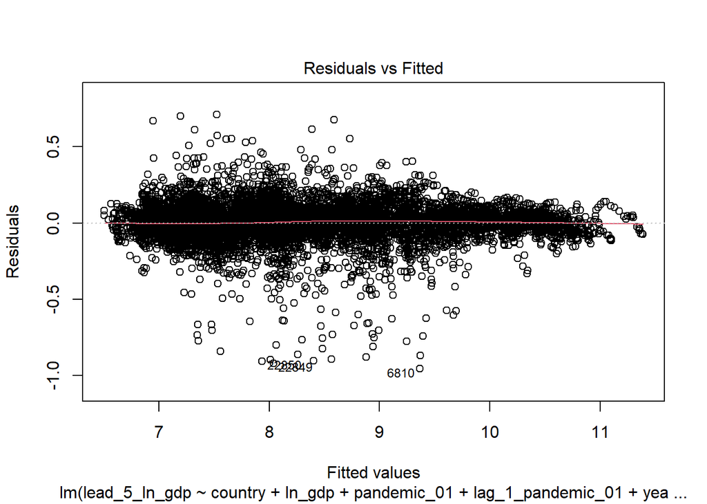

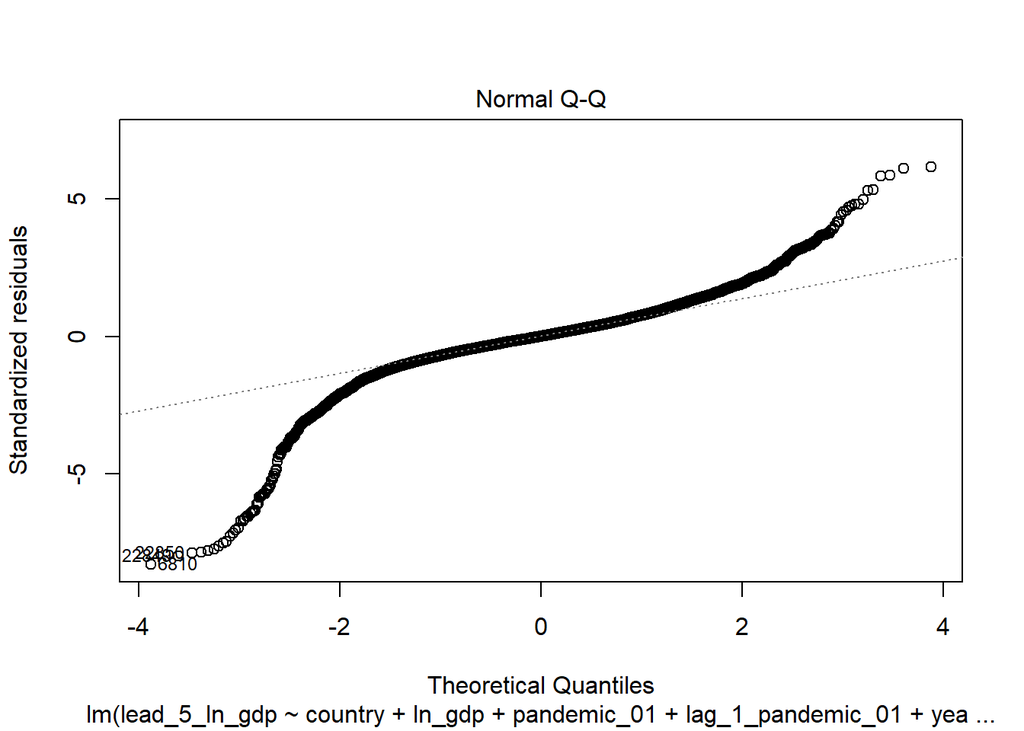

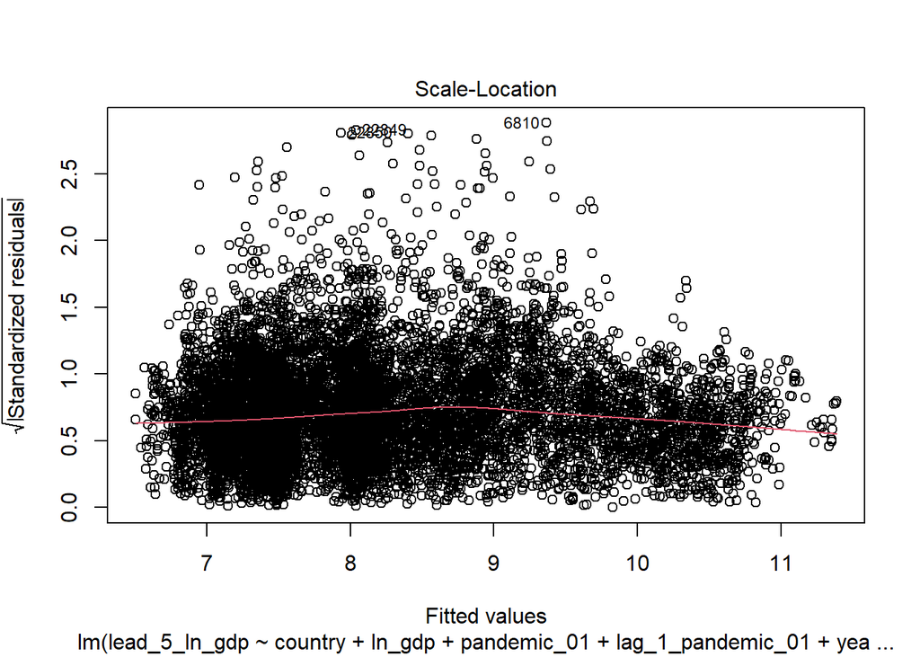

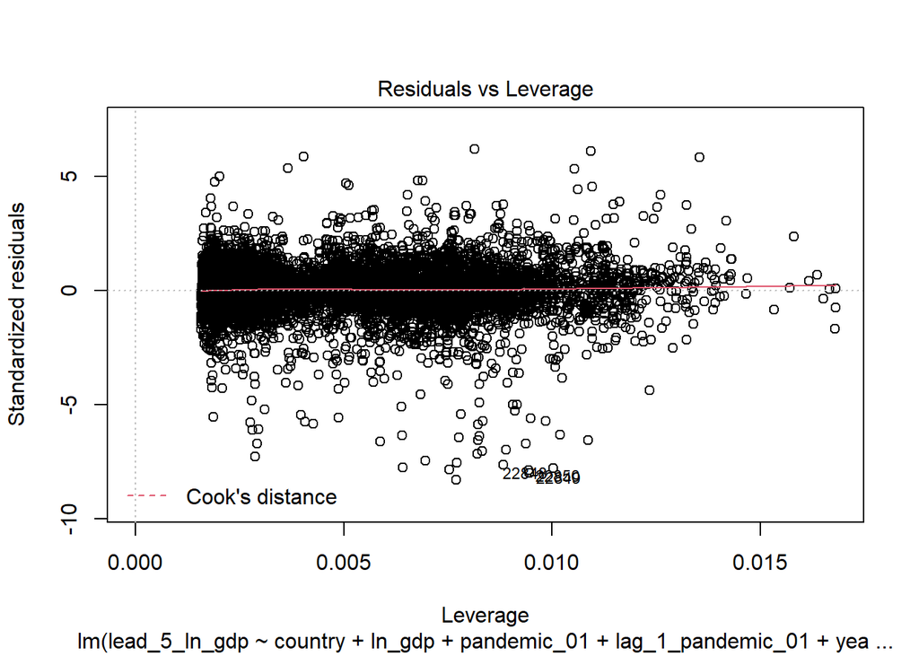

```r
plot(reg3)
```

```r
lmtest::dwtest(reg3)
```

```
##
##  Durbin-Watson test
##
## data:  reg3
## DW = 0.53196, p-value < 2.2e-16
## alternative hypothesis: true autocorrelation is greater than 0
```

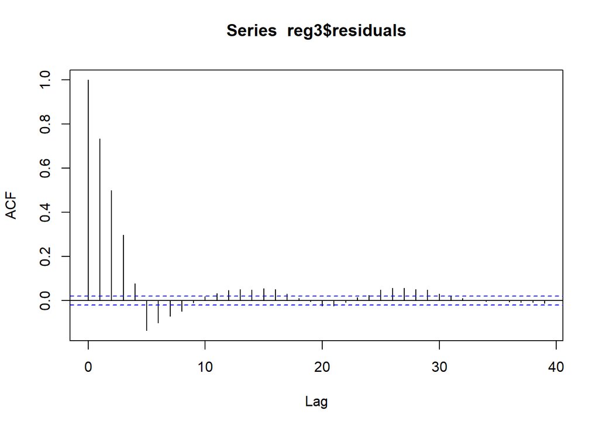

```r
plot(acf(reg3$residuals))
```

Figurene over viser samlet sett en ganske dårlig modelltilnærming. Kanskje de viktigste er:

- Ikke normalfordelte residualer (ref: QQ-normalplott)
- Det er autokorrelasjon i feilleddet (her også testet med en Durbin-Watson test). Modellen klarer altså ikke å fange opp hvordan BNP utvikler seg i tid, selv etter justering for lineære trender og inkludering av BNP ved tid $t$ som forklaringsvariabel.
- Ut fra residualplottet kan vi se *antydninger* til heteroskedastisitet ved variansen til residualene avtar når BNP øker.

## Oppgave 3

La oss for enkelthetsskyld se bort fra alle forklaringsvariabler bortsett fra $W_{i,t}$ i modellen (Konklusjonen gjelder ellers også) slik at den “sanne” modellen når $U_i$ inkluderes faktisk er

$$Y_{i,t + 5} = \alpha_i + \beta_0 + \beta_3 W_{i,t} + \delta U_{i,t} + \epsilon_{i,t}$$
Setter vi inn $\delta_0 + \delta_1W_{i,t} + \eta_{i,t}$ for $U_{i,t}$ får vi at den sanne modellen kan skrives som:

$$Y_{i,t + 5} = \alpha_i + \beta_0 + \beta_3 W_{i,t} + \delta (\delta_0 + \delta_1W_{i,t} + \eta_{i,t}) + \epsilon_{i,t}\\ = \alpha_i + (\beta_0 +\delta\delta_0) + (\beta_3 + \delta\delta_1)W_{i,t} + (\epsilon_{i,t} + \delta\eta_{i,t}) \\
=\alpha_i + \beta^*_0 + \beta^*_3W_{i,t} + \epsilon^*_{i,t}$$

Det betyr at når vi utelater $U_{i,t}$ fra modellen så vil estimatet $\hat{\beta}_3^{OLS}$ faktisk være et estimat av $\beta^*_3 = \beta_3 + \delta\delta_1$, som da ikke er effekten av krig alene, men også den indirekte effekten av den utelatte variabelen $U_{i,t}$. $\hat{\beta}_3^{OLS}$ er derfor både forventningsskjev og inkonsistent (dvs vi kan ikke forvente at verdien nærmer seg den sanne verdien selv når datasettet blir meget stort). Mer spesifikt, ut fra formelen for $\beta^*_3$ ser vi at dersom $\delta$ og $\delta_1$ er positive vil vi overestimere den sanne effekten ($\beta_3$).

OBS: I oppgaveteksten mangler $\beta_0$ i den sanne modellen. Dette ble det sendt ut melding om på Canvas. De som har løst oppgaven uten denne vil selvsagt ikke få noen trekk. Utrykket for $\beta^*_3$ blir uansett det samme.

## Oppgave 4

I datasettet studentene har fått kan man enkelt beregne impuls responser ved å gjenta en av regresjonene over, men med ulike leads på den avhengige variabelen. I det utleverte datasettet har studentene verdiene 2,5,8,11,14 og 17I koden under kjøres fire av variantene, der vi kan lese impuls-responsen direkte ut fra tabellen på koeffisientene til `pandemic_01`:

```r
reg_2 <-
  df %>%
  lm(
    lead_2_ln_gdp ~ country  + ln_gdp + pandemic_01 + lag_1_pandemic_01 + year + war + lag_1_war
    + vienna + oil + ww2 + vienna_t + oil_t + ww2_t ,
    data = .
  )
reg_5 <-
  df %>%
  lm(
    lead_5_ln_gdp ~ country  + ln_gdp + pandemic_01 + lag_1_pandemic_01 + year + war + lag_1_war
    + vienna + oil + ww2 + vienna_t + oil_t + ww2_t ,
    data = .
  )
reg_8 <-
  df %>%
  lm(
    lead_8_ln_gdp ~ country  + ln_gdp + pandemic_01 + lag_1_pandemic_01 + year + war + lag_1_war
    + vienna + oil + ww2 + vienna_t + oil_t + ww2_t ,
    data = .
  )
reg_11 <-
  df %>%
  lm(
    lead_11_ln_gdp ~ country  + ln_gdp + pandemic_01 + lag_1_pandemic_01 + year + war + lag_1_war
    + vienna + oil + ww2 + vienna_t + oil_t + ww2_t ,
    data = .
  )
stargazer::stargazer(reg_2,reg_5,reg_8,reg_11, type="html", omit="country")
```

|  | *Dependent variable:* |  |  |  |
| --- | --- | --- | --- | --- |
|  | lead_2_ln_gdp | lead_5_ln_gdp | lead_8_ln_gdp | lead_11_ln_gdp |
|  | (1) | (2) | (3) | (4) |
| ln_gdp | 0.942*** | 0.878*** | 0.829*** | 0.795*** |
|  | (0.003) | (0.005) | (0.006) | (0.006) |
| pandemic_01 | 0.017*** | 0.022** | 0.034*** | 0.041*** |
|  | (0.006) | (0.009) | (0.010) | (0.011) |
| lag_1_pandemic_01 | 0.004 | 0.021** | 0.029*** | 0.025** |
|  | (0.006) | (0.009) | (0.010) | (0.011) |
| year | 0.00004*** | 0.0001*** | 0.0001*** | 0.0001*** |
|  | (0.00001) | (0.00001) | (0.00002) | (0.00002) |
| war | -0.011*** | -0.015*** | -0.013*** | -0.001 |
|  | (0.003) | (0.004) | (0.005) | (0.005) |
| lag_1_war | 0.001 | 0.002 | 0.009* | 0.004 |
|  | (0.003) | (0.004) | (0.005) | (0.005) |
| vienna | -0.939*** | -2.194*** | -3.255*** | -4.215*** |
|  | (0.102) | (0.146) | (0.171) | (0.188) |
| oil | 0.476 | 0.823 | -0.245 | -5.547*** |
|  | (0.761) | (1.110) | (1.341) | (1.535) |
| ww2 | -1.344** | -2.584*** | -3.214*** | -0.367 |
|  | (0.683) | (0.970) | (1.132) | (1.239) |
| vienna_t | 0.001*** | 0.001*** | 0.002*** | 0.002*** |
|  | (0.0001) | (0.0001) | (0.0001) | (0.0001) |
| oil_t | -0.0003 | -0.0005 | 0.0001 | 0.003*** |
|  | (0.0004) | (0.001) | (0.001) | (0.001) |
| ww2_t | 0.001** | 0.001*** | 0.002*** | 0.0003 |
|  | (0.0003) | (0.0005) | (0.001) | (0.001) |
| Constant | 0.376*** | 0.789*** | 1.084*** | 1.295*** |
|  | (0.026) | (0.038) | (0.044) | (0.049) |
| Observations | 9,773 | 9,637 | 9,512 | 9,405 |
| R<sup>2</sup> | 0.994 | 0.987 | 0.983 | 0.979 |
| Adjusted R<sup>2</sup> | 0.994 | 0.987 | 0.983 | 0.979 |
| Residual Std. Error | 0.081 (df = 9728) | 0.116 (df = 9592) | 0.135 (df = 9467) | 0.147 (df = 9360) |
| F Statistic | 34,655.680*** (df = 44; 9728) | 16,916.350*** (df = 44; 9592) | 12,263.400*** (df = 44; 9467) | 10,131.410*** (df = 44; 9360) |
| *Note:* | p<0.1; p<0.05; p<0.01 |  |  |  |

For kompletthetens skyld kan vi reprodusere figur 9 i paperet, og i tillegg også tegne impuls responsen til `War`. I det store og det hele er det resultatene meget like, til tross for at modellen her er betydelig enklere. Det er *ikke* forventet at studentene gjør dette - besvarelser som kun bruker variablene som er levert i oppgaven vil kunne få full uttelling.

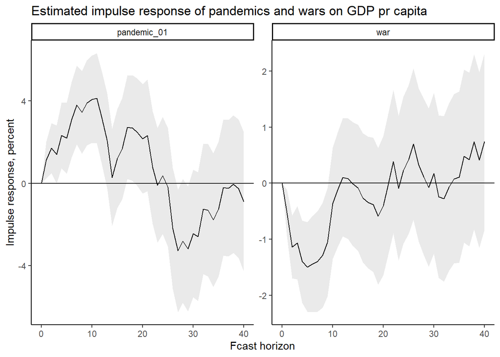

```r
runreg <-
  function(h, df) {
    df_raw %>%
      select(country, year, ln_gdp, pandemic_01, pandemic_pc, war) %>%
      mutate(country = factor(country)) %>%
      group_by(country) %>%
      mutate(
        lead_ln_gdp = lead(ln_gdp, h, order_by = year),
        lag_1_pandemic_01 = lag(pandemic_01, 1, order_by = year),
        lag_1_war = lag(war, 1, order_by = year),
        vienna = case_when(year >= 1815 ~ 1, TRUE ~ 0),
        ww2 = case_when(year >= 1945 ~ 1, TRUE ~ 0),
        oil = case_when(year >= 1973 ~ 1, TRUE ~ 0),
        vienna_t = vienna * year,
        ww2_t = ww2 * year,
        oil_t = oil * year
      ) %>%
      ungroup %>%
      lm(
        lead_ln_gdp ~ country + ln_gdp + pandemic_01 + lag_1_pandemic_01 + year + war + lag_1_war
        + vienna + oil + ww2 + vienna_t + oil_t + ww2_t ,
        data = .
      ) %>%
      summary %>%
      .$coefficients %>%
      as.data.frame() %>%
      rownames_to_column() %>%
      as_tibble %>%
      mutate(h = h)
  }

lapply(0:40, FUN = runreg, df = df) %>%
  bind_rows() %>%
  filter(rowname %in% c("pandemic_01", "war")) %>%
  ggplot(aes(x = h)) +
  geom_line(aes(y = Estimate * 100)) +
  geom_ribbon(aes(
    ymin = (Estimate - 1.96 * `Std. Error`) * 100,
    ymax = (Estimate + 1.96 * `Std. Error`) * 100
  ), alpha = .1) +
  geom_hline(yintercept = 0) +
  xlab("Fcast horizon") +
  ylab("Impulse response, percent") +
  ggtitle("Estimated impulse response of pandemics and wars on GDP pr capita") +
  facet_wrap( ~ rowname, scales = "free_y") +
  theme_classic()
```

- Dersom casen i Oppgave 3 faktisk stemmer og det finnes en slik uobservert variabel er det klart at vi i liten grad kan stole på at estimatene fra modellen fanger opp den kausale effekten av pandemier på BNP per capita. Det er ikke mulig for oss å teste om det finnes en slik utelatt variabel, og eventuelt om den vil endre resultatene - med mindre vi kan kjøre randomiserte eksperimenter. Dermed er vi til syvende og sist avhengig av om vi *tror* på om resultatene er gyldig eller ikke.
- Fra 4 har vi at vi klarer å reprodusere figurene fra paperet - men dette påvirker ikke innvendingen over.

I denne oppgaven relativt åpen og vi er derfor åpne for gode diskusjoner i besvarelsen.